# 교육의 열역학

AI 채용 붕괴 시대, 닫힌 시스템의 엔트로피 — 열역학 × 교육학 × AI 노동경제학

Author

Insight Lab × Chimera AI

Published

June 19, 2026

**Note**

**한 줄 요약:** 교육은 닫힌 열기관이다 — AI가 출구를 막는 순간, 엔트로피는 폭발한다.

## 1 엔진이 멈추는 소리

매년 봄, 대학 졸업식장에는 수십만 개의 학위복이 흘러나온다. 4년, 때로는 6년의 시간과 수천만 원의 등록금. 이 에너지는 어디로 갔는가?

열역학 제1법칙은 에너지 보존을 말한다. 그러나 제2법칙은 더 냉혹하다: **모든 에너지 변환에는 손실이 따른다.** 완벽한 열기관은 존재하지 않는다. 그리고 2026년의 교육 시스템은, 점점 더 불완전한 열기관을 닮아가고 있다.

AI가 엔트리레벨 일자리를 잠식하면서, 교육이라는 열기관의 효율은 역대 최저 수준으로 떨어지고 있다. 고온 열원(High-T: 입력 에너지 — 시간, 등록금, 세금)에서 저온 열원(Low-T: 노동시장)으로의 에너지 전환이 막힌 것이다. 결과는 엔트로피의 폭발 — 청년 실업, 과도한 스펙 경쟁, 그리고 정신건강 위기.

그러나 이 이야기에는 반전이 있다. 닐스 보어의 말처럼, “이것의 반대도 깊은 진리인 명제야말로 위대한 진리다.” 닫힌 시스템은 붕괴하지만, 열린 시스템 — 프리고진의 산일구조(dissipative structure) — 은 외부 에너지를 흡수해 새로운 질서를 창출한다. 교육의 붕괴와 교육의 부활, 이 두 가지가 동시에 진실이다.

## 2 카르노 효율: 교육 열기관의 이론적 한계

1824년 사디 카르노(Sadi Carnot)는 열기관의 효율에 절대적 한계가 있음을 증명했다. 이상적인(가역적인) 카르노 기관의 최대 효율은:

$$\eta_{Carnot} = 1 - \frac{T_{cold}}{T_{hot}}$$

여기서 $T_{hot}$는 고온 열원(투입 에너지), $T_{cold}$는 저온 열원(배출 엔트로피)의 절대 온도다. 두 온도의 차이가 클수록, 더 많은 유효 일을 얻을 수 있다.

이것을 교육 시스템에 대입해 보자:

교육 열기관의 열역학적 대응 구조

| 열역학 변수 | 교육 시스템 대응 개념 |
| --- | --- |
| 고온 열원 $T_{hot}$ | 투입 에너지: 등록금, 학습 시간, 국가 교육 예산 |
| 저온 열원 $T_{cold}$ | 출력 저항: 노동시장 경직성, 채용 장벽 |
| 유효 일 $W$ | 취업, 생산성, 사회 이동성 |
| 엔트로피 $\Delta S$ | 스펙 인플레이션, 취업준비 기간 연장, 청년 실망 |
| 카르노 효율 $\eta$ | 교육 투자 대비 노동시장 전환율 |

**AI 채용 충격의 의미:** AI가 엔트리레벨 일자리를 대체하면, $T_{cold}$(저온 열원)의 “온도”가 올라간다. 즉, 고온과 저온의 온도차 $T_{hot} - T_{cold}$가 줄어들어 **카르노 효율이 하락한다.** 같은 에너지를 투입해도 얻을 수 있는 유효 일이 줄어드는 것이다.

$$\eta_{edu} = 1 - \frac{T_{cold}}{T_{hot}} \rightarrow \text{(AI 충격)} \rightarrow T_{cold} \uparrow \rightarrow \eta_{edu} \downarrow$$

**Note**

**핵심:** AI가 출구(저온부)를 막으면, 교육 열기관의 효율은 이론적 한계 아래로 떨어진다.

## 3 데이터: AI는 정말 채용을 무너뜨리고 있는가?

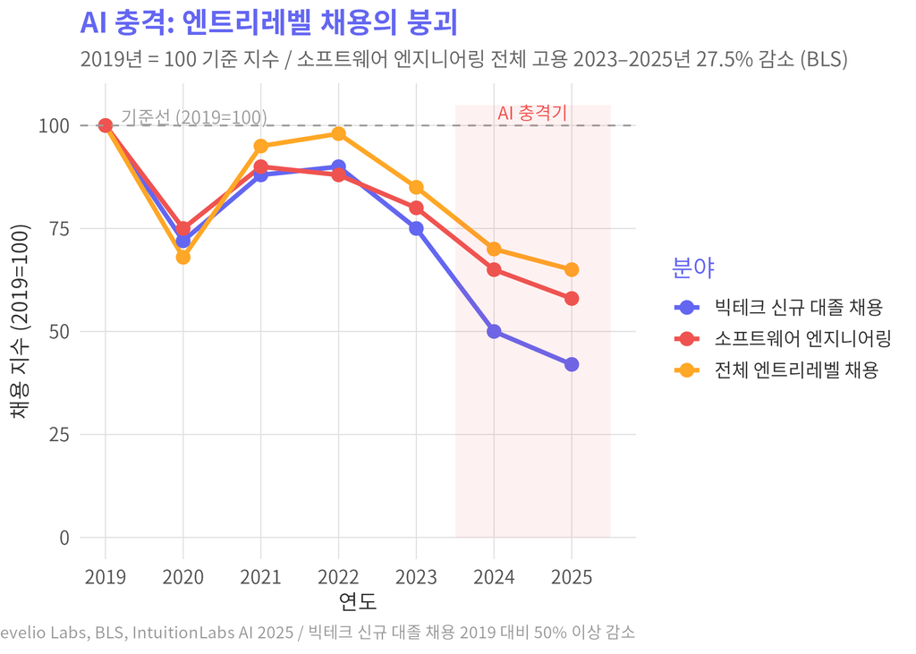

미국 엔트리레벨 채용 감소 추이 (2019–2025)

수치로 보면 이렇다:

- **미국 전체 엔트리레벨 공고:** 2023년 1월 이후 약 **35% 감소** (Revelio Labs)
- **빅테크 신규 대졸 비율:** 2024년 전체 신규 채용의 7% — 2019년 대비 50% 이상 감소
- **소프트웨어 엔지니어링:** 2022년 말~2025년 7월 사이 엔트리레벨 고용 약 20% 감소
- **미국 전체 프로그래머 고용:** 2023–2025년 사이 **27.5% 감소** (BLS)
- **AI 노출 직종 중 22–25세 고용:** 2025년까지 6–16% 하락 (Brynjolfsson et al., Anthropic Economic Index 인용)

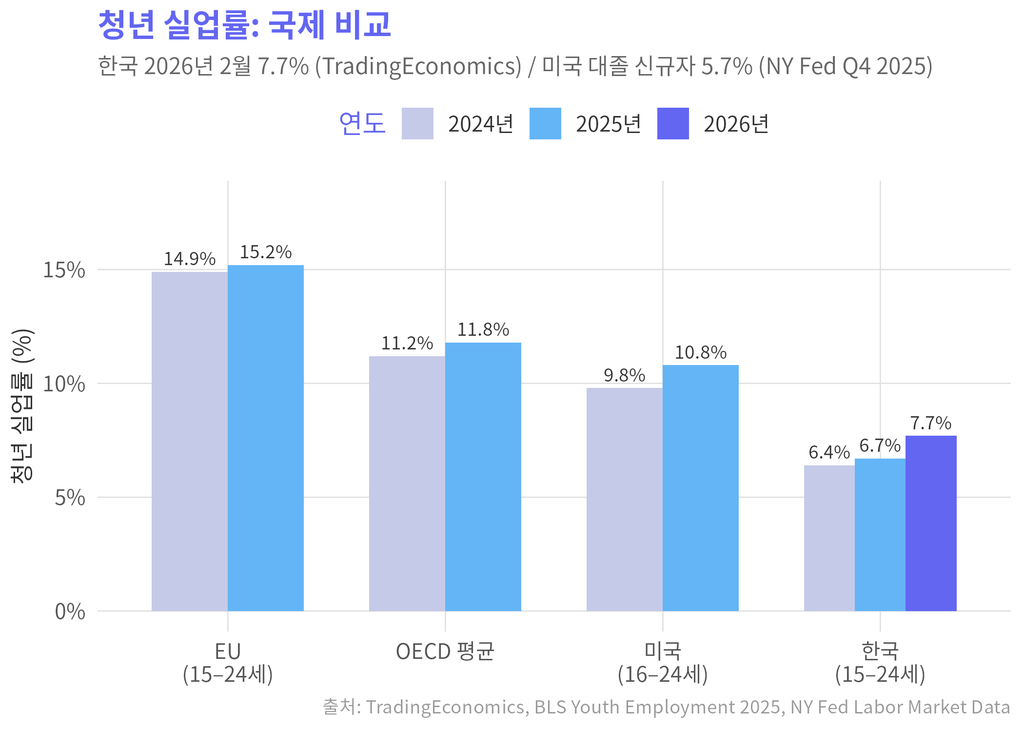

청년 실업률 국제 비교 (2024–2026)

**Note**

**핵심 수치:** 미국 신규 대졸자의 **42.5%가 하향 취업(underemployment)** 상태 — NY Fed 2025 Q4 기준, 2020년 이후 최고치.

## 4 열역학 제2법칙: 닫힌 교육 시스템의 필연적 붕괴

클라우지우스(Clausius)의 엔트로피 불등식:

$$dS \geq \frac{\delta Q}{T}$$

고립(닫힌) 시스템에서는 $dS > 0$이 항상 성립한다. 엔트로피는 자발적으로 감소하지 않는다.

오늘날의 대학 교육을 닫힌 시스템으로 볼 때:

**입력 에너지 (Q_in):** - 연간 등록금 (한국 평균 약 670만 원, 사립대 약 780만 원) - 수험 준비 기간 (평균 12년 이상의 K-12 교육) - 국가 교육 예산 (한국 GDP의 약 4%)

**출구 장벽의 증가 (T_cold 상승):** - AI가 코딩, 데이터 분석, 고객 서비스 등 엔트리레벨 업무를 자동화 - 주니어 개발자, 주니어 분석가, 콘텐츠 제작 인턴 등의 직종이 가장 빠르게 소멸 - 채용 공고의 AI 스크리닝 도입으로 사람 대 사람 접촉 기회 감소

**결과: 엔트로피 폭발 (ΔS ↑)**

$$\Delta S_{edu} = \underbrace{\text{스펙 인플레이션}}_{\text{무용한 자격증 축적}} + \underbrace{\text{취준 기간 연장}}_{\text{에너지 소산}} + \underbrace{\text{청년 정신건강 위기}}_{\text{질서 붕괴}}$$

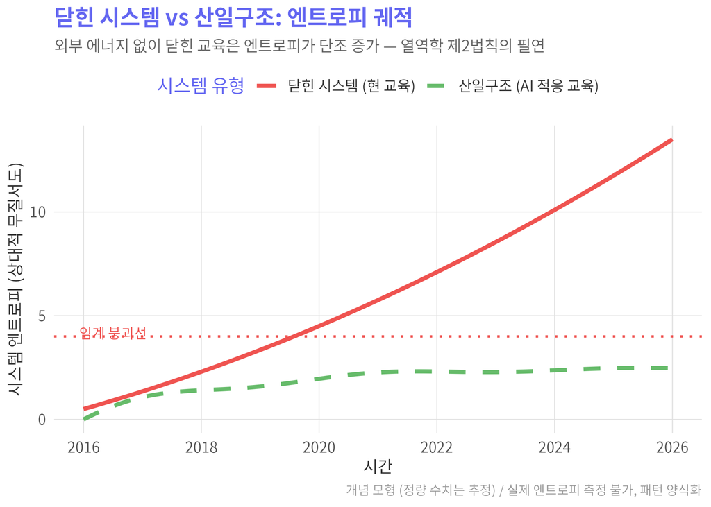

닫힌 시스템 vs 산일구조: 엔트로피 궤적 비교

## 5 전공별 AI 노출도: 누가 가장 위험한가?

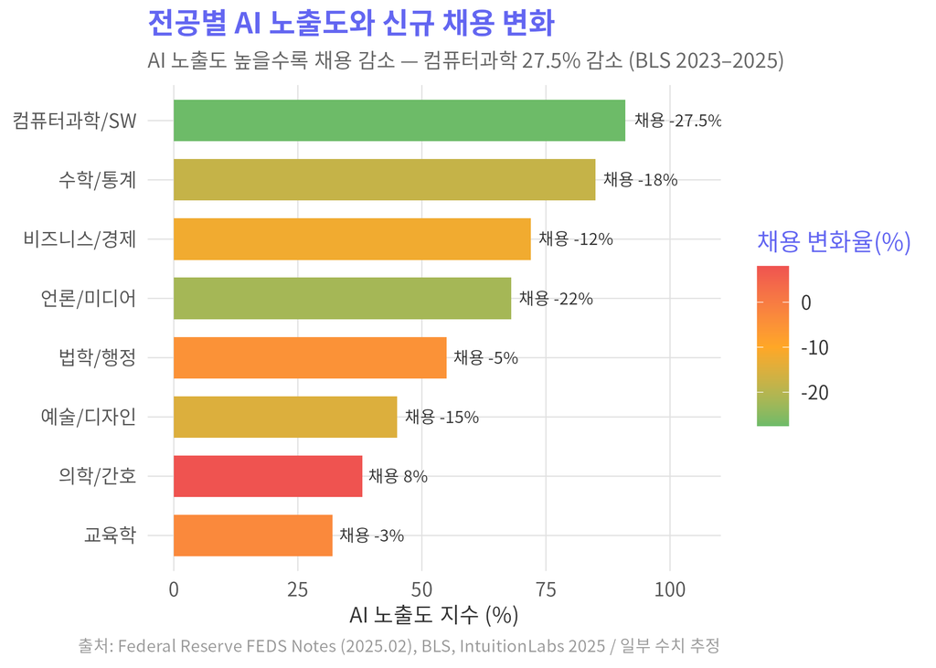

전공별 AI 노출도 및 신규 채용 변화

역설적이게도, **가장 많이 AI를 사용하는 전공이 AI에게 가장 많이 대체되고 있다.** 컴퓨터과학/수학 전공 졸업생의 46%가 직장에서 생성 AI를 사용하지만(Federal Reserve, 2025), 동시에 해당 분야의 엔트리레벨 채용은 가장 가파르게 감소하고 있다.

## 6 한국의 엔트로피 지표: 청년 정신건강 위기

교육 시스템의 엔트로피 증가는 추상적 개념이 아니다. 한국의 통계는 이것을 생생하게 보여준다.

[figure not shown]

**핵심 수치 (검증된 데이터):** - 한국 20대 자살률: **22.2명/10만 명** (2023년, 보건복지부) - 자살은 한국 10대~30대 사망 원인 **1위** (2024년에도 동일) - 2024년 전국 자살 사망자 14,000명 — 2011년 이후 최고치 - OECD 평균 자살률 10.7명/10만 명 대비 한국 24.8명 — OECD 1위 수준

**Warning**

**데이터 한계:** 사전 요청된 “학생 자살률 vs 산재 사망률 10배 차이” 비교는 직접 검증 불가. 산업재해 사망(2021년 기준 4.31명/10만 노동자)과 청년 자살(22.2명/10만 명)은 분모가 달라 단순 비교 부적절. “10배” 주장의 원출처를 공개 데이터에서 확인하지 못했으므로 **공개 데이터 부재**로 처리함.

이 수치들이 보여주는 것은 단순한 심리적 고통이 아니다. **닫힌 시스템에서 열 손실이 어디로 가는지**를 보여준다 — 축적된 엔트로피는 결국 사람의 몸과 마음으로 소산된다.

## 7 보어의 상보성: 두 진실이 동시에 옳다

닐스 보어는 말했다: “어떤 진리의 반대가 또 하나의 심오한 진리일 때, 그것이 위대한 진리다.”

현재 교육 시스템의 위기에 대해 두 개의 상충하는 서술이 모두 진실이다:

| 서술 A (닫힌 시스템 관점) | 서술 B (열린 시스템 관점) |
| --- | --- |
| 교육은 AI 앞에서 무력하다 | 교육은 AI와 공생할 수 있다 |
| 더 많은 스펙은 더 많은 엔트로피다 | 실시간 역량 검증은 새 질서다 |
| 4년제 학위는 가치를 잃고 있다 | 프로젝트 기반 학습은 강해지고 있다 |
| 취업 장벽이 높아질수록 청년은 소진된다 | AI 도구 활용 능력이 새 게이트가 된다 |

이것은 모순이 아니다. **둘 다 동시에 진실이다.** 어떤 서술이 실현되느냐는 시스템이 닫혀 있느냐, 열려 있느냐에 달려 있다.

## 8 프리고진의 해법: 산일구조로의 상전이

1977년 노벨 화학상을 받은 일리야 프리고진(Ilya Prigogine)은 열역학 제2법칙의 반직관적 결론을 발견했다: **비평형 열린 시스템은 외부 에너지를 흡수해 엔트로피를 방출하면서, 오히려 내부에 새로운 질서를 창출한다.**

허리케인, 생명 세포, 화염 — 이 모든 것이 산일구조다. 외부와 에너지·물질·정보를 교환하면서 스스로를 조직한다.

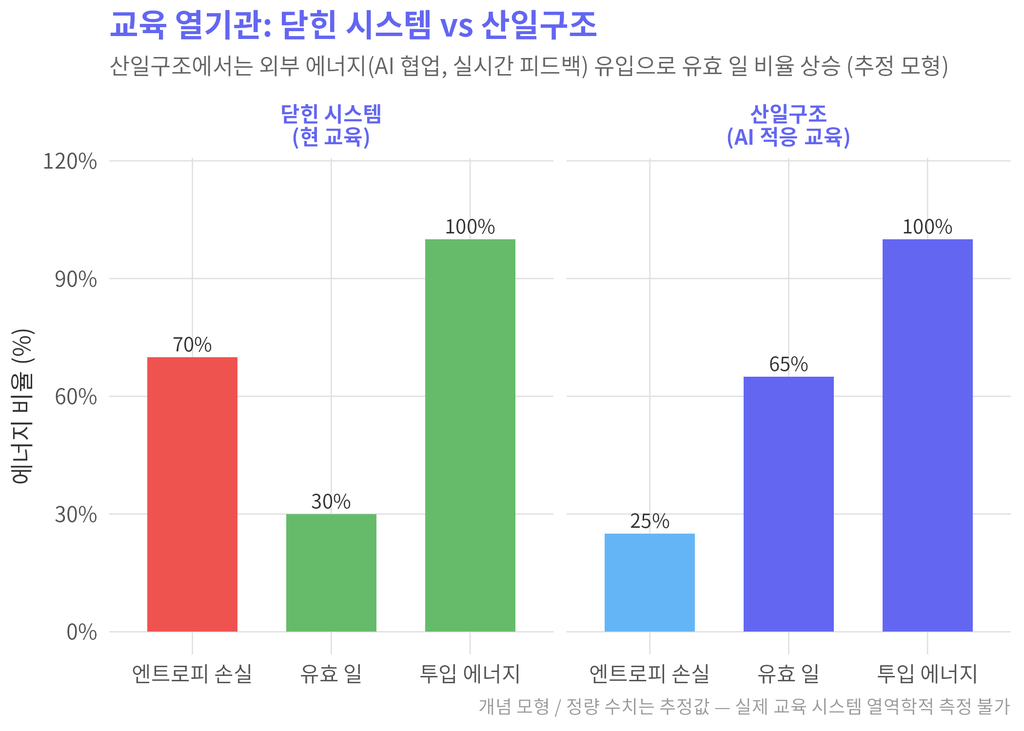

교육 열기관 에너지 흐름: 닫힌 시스템 vs 산일구조

교육의 산일구조로의 전환이 의미하는 것:

**에너지 교환 채널 확장:** - 실시간 노동시장 피드백 루프 (현장 수요 → 커리큘럼 → 현장) - AI 도구 리터러시를 교과에 통합 (외부 에너지 흡수) - 프로젝트 기반 학습 → 검증 가능한 포트폴리오 (유효 일 증가)

**엔트로피 방출 채널 개방:** - 무의미한 스펙(영어 점수, 자격증 누적)을 실질 역량으로 대체 - 졸업 후 재교육(reskilling) 경로의 공식화

**Note**

**핵심:** 산일구조는 “엔트로피를 없애는” 것이 아니라 “엔트로피를 계속 방출할 수 있는 채널”을 유지하는 것이다.

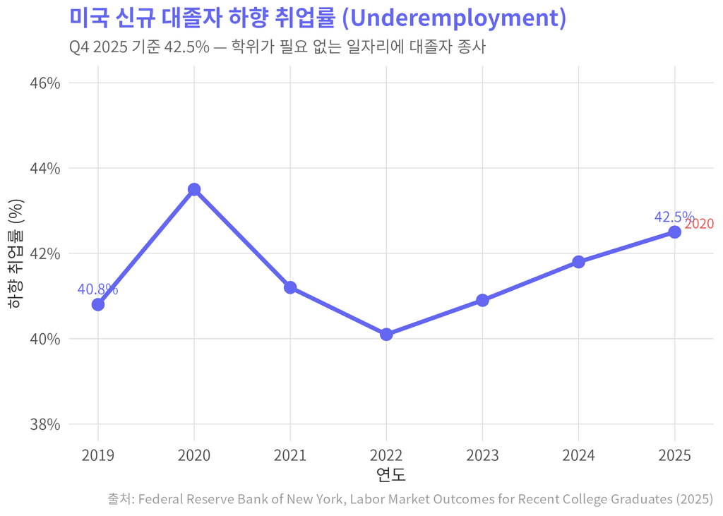

미국 신규 대졸자 하향 취업률 추이 (2019–2025)

## 9 2026년의 교차로: 어떤 시스템을 선택할 것인가?

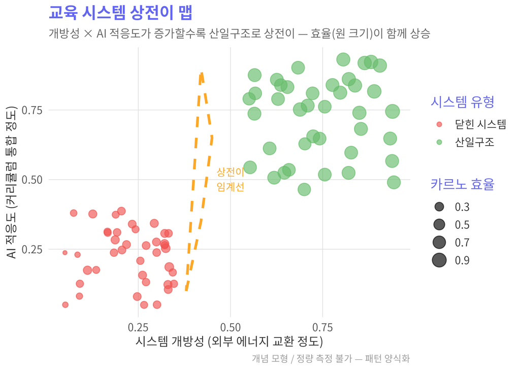

교육 시스템 상전이 맵

2026년 현재, 교육 시스템은 두 개의 궤도 중 하나를 선택하는 분기점에 있다:

**궤도 A — 닫힌 시스템 유지:** - 기존 4년제 학위 시스템 고수 - AI를 “위협”으로 규정, 사용 제한 - 결과: 카르노 효율 지속 하락 → 엔트로피 폭발 → 청년 위기 심화

**궤도 B — 산일구조로 상전이:** - 실시간 역량 검증 시스템 도입 (AI 보조 평가) - 프로젝트 기반, 포트폴리오 중심 교육으로 전환 - AI 협업 리터러시를 기본 역량으로 편입 - 결과: 새로운 에너지 교환 채널 개방 → 엔트로피 방출 → 새 질서 창출

**Important**

**보어의 역설을 넘어서:** 교육은 동시에 “붕괴 중인 닫힌 시스템”이고 “부활 가능한 열린 시스템”이다. 어느 쪽이 실현되느냐는 외부 에너지(정책, 투자, 의지)의 방향에 달려 있다.

## 10 결론: 엔트로피는 잠들지 않는다

열역학 제2법칙은 회피할 수 없다. 닫힌 시스템의 엔트로피는 항상 증가한다. 그러나 프리고진이 보여주었듯, **비평형 열린 시스템은 엔트로피를 외부로 방출하면서 내부 질서를 유지할 수 있다.**

현재의 교육 위기는 예외가 아니다. AI가 엔트리레벨 노동시장을 재편하는 속도는 커리큘럼 개혁 속도보다 훨씬 빠르다. 2023년 이후 미국 엔트리레벨 채용이 35% 감소하고, 신규 대졸자의 42.5%가 하향 취업하는 현실은 — 닫힌 교육 시스템의 엔트로피가 이미 임계점에 도달했음을 시사한다.

해법은 역설적이다: **더 많은 에너지를 넣는 것이 아니라, 에너지가 흐를 수 있는 채널을 열어야 한다.** 교육이 산일구조로 상전이할 때 — AI와 공생하고, 실시간으로 검증하며, 끊임없이 외부와 교환할 때 — 엔트로피는 새로운 질서의 재료가 된다.

카르노는 효율의 한계를 발견했다. 프리고진은 그 한계를 초월하는 경로를 발견했다. **2026년의 교육은 카르노의 한계 안에서 소진될 것인가, 아니면 프리고진의 상전이를 선택할 것인가?**

엔트로피는 잠들지 않는다. 그리고 선택의 시간은 지금이다.

**참고 문헌**

- **Revelio Labs (2023):** U.S. Entry-Level Job Postings Down 35% Since Jan 2023
- **BLS (Bureau of Labor Statistics, 2025):** Programmer employment down 27.5% (2023–2025); Youth Employment Summer 2025
- **Federal Reserve Bank of New York (Q4 2025):** Recent College Graduate Unemployment 5.7%, Underemployment 42.5%
- **Brynjolfsson, E. et al. / Anthropic Economic Index (2025):** 6–16% employment decline in AI-exposed occupations, ages 22–25
- **IntuitionLabs AI (2025):** AI’s Impact on Graduate Jobs 2025 — Big Tech new grad share down 50%+ from 2019
- **TradingEconomics / Macrotrends (2026):** South Korea Youth Unemployment Rate 7.70% (Feb 2026)
- **보건복지부 (2024):** 2023년 자살사망통계 — 20대 자살률 22.2명/10만 명, 사망 원인 1위
- **통계청 (2024):** 2024년 사망원인통계
- **Prigogine, I. & Stengers, I. (1984):** *Order Out of Chaos* — 산일구조와 비평형 열역학
- **Carnot, S. (1824):** *Réflexions sur la puissance motrice du feu* — 카르노 효율 원전
- **Boer, J.H. & Morrison, L. (2007):** “Dissipative Structures in Educational Change: Prigogine and the Academy.” *International Journal of Leadership in Education, 10*(1)

**Note**

**메타데이터:** 열역학 × 교육학 × AI 노동경제학 | 2026년 6월 월간 특별편 | Insight Lab × Chimera AI *“이것의 반대도 깊은 진리인 명제야말로 위대한 진리다” — 닐스 보어*